# Report

Shweta Srikanth

# Explantory Data Analysis

## Bar Charts

### Bar Chart of Energy Level Category

The Energy level of that species of dog is categorized into 5 different categories- Couch potato, Calm, Regular Exercise, Energetic and Needs lots of activity in order of increasing energy level. We see below a bar chart of the different categories.

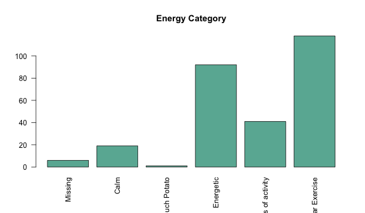

Energy Level Bar Chart

### Bar Chart of Demeanor Category

The demeanor of the species is categorzied into 5 different categories- Aloof/wary, Reserved with strangers, Alert/Responsive, Friendly and Outgoing, in increasing order of level of friendliness. We have plotted below a bar chart of the different categories.

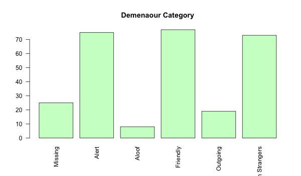

Demeanor Bar Chart

### Bar chart of trainability category

The trainability of the species is categorized into 5 different categories- May be stubborn, Independent, Agreeable, Easy Training, Eager to Please in increasing order of ease of trainability.

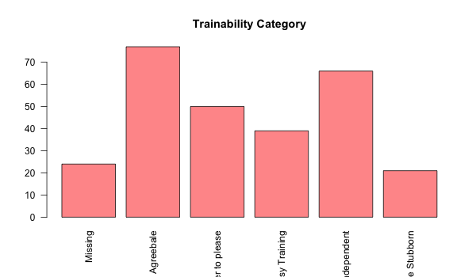

Trainability Bar Chart

### Bar chart of shedding level category

The shedding level of a species is categorized into 5 categories- Infrequent, Occasional, Seasonal, Regularly and Frequent in increasing order of shedding levels.

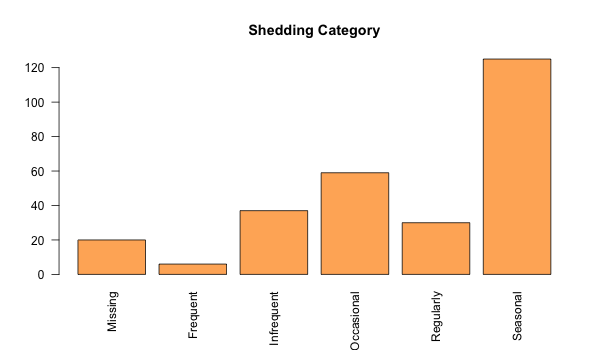

Shedding Level Bar Chart

### Bar Chart of grooming frequency category

The frequency of grooming required for a species of dog is categorized into 5 categories- Occasional Bath/Brush, Weekly Brushing, 2-3 times a week brushing, Daily brushing and Professional, in increasing order of level of grooming.

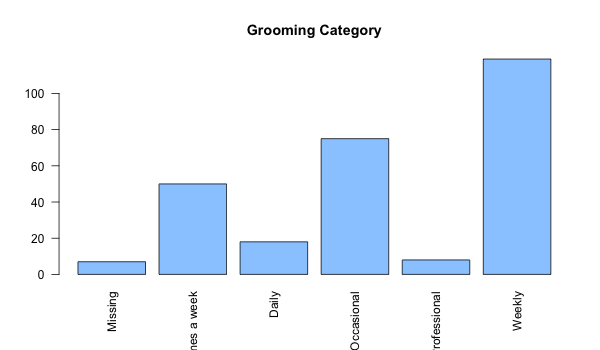

Grooming Level Bar Chart

### Scatter plot for Average height and weight

Using the minimum and maximum height and weight, the average height and weight has been computed. Using this a scatter plot between the two has been produces.

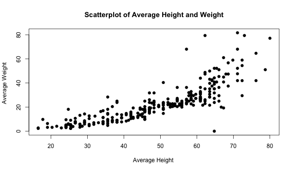

As expected, in general, as the height of the dog increases, so does the weight.